# Application of process mining and logistic regression to a data set of sepsis managment from admission to discharge

Lauren Flemmer and Hilda Klasky

### Outline

- Overview of the data
- Data analysis and visualization
- Model building
- Model testing and validation

### Sepsis

Sepsis is a condition that occurs when the body’s response to an infection begins to damage its own tissues. Sepsis is extremely life threatening, with around a 40% mortality rate due to its ability to damage organs and cause them to fail. As sepsis becomes worse, blood flow to the brain, heart, kidneys, and other organs decrease. Treatment for sepsis includes antibiotics and to maintain blood flow to organs.

### Process Mining

Process mining is a field of data science that allows us to visualize and analyze event logs. Given a data set with case id, event id, and time stamp columns, process mining algorithms, (Alpha Algorithm, Heuristics Miner, Genetic Miner, etc.) generate event logs. These event logs can then be turned into process maps, which allow us to visualize how processes occur, as well as identify any bottlenecks or inefficiencies.

The goal of this study is to analyze and better understand event data through process mining. Additionally, we hope to combine logistic regression and process mining to create a model that is both accurate and meaningful. This analysis was completed using the **RStudio** application (https://www.rstudio.com/) and the **BupaR** package (https://www.bupar.net/). _______________________________________________________________________________________________________________________________

### The Data

The data used for this analysis is a real patient event log obtained from **BupaR’s eventdataR package**, and describes **management of sepsis patients**, from their admission to their discharge.

The details and descriptive statistics of the data are as follows:

```
## Log of 5 events consisting of:
## 1 trace
## 1 case
## 5 instances of 5 activities
## 1 resource
## Events occurred from 2014-10-22 11:15:41 until 2014-10-22 11:33:37
##
## Variables were mapped as follows:
## Case identifier:     case_id
## Activity identifier:     activity
## Resource identifier:     resource_id
## Activity instance identifier:    activity_instance_id
## Timestamp:           timestamp
## Lifecycle transition:        lifecycle_id
##
## # A tibble: 5 x 36
##   case_id activity lifecycle resource timestamp             age   crp diagnose
##   <chr>   <fct>    <fct>     <fct>    <dttm>              <int> <dbl> <chr>
## 1 A       ER Regi… complete  A        2014-10-22 11:15:41    85    NA A
## 2 A       Leucocy… complete  B        2014-10-22 11:27:00    NA    NA <NA>
## 3 A       CRP      complete  B        2014-10-22 11:27:00    NA   210 <NA>
## 4 A       LacticA… complete  B        2014-10-22 11:27:00    NA    NA <NA>
## 5 A       ER Tria… complete  C        2014-10-22 11:33:37    NA    NA <NA>
## # … with 28 more variables: diagnosticartastrup <chr>, diagnosticblood <chr>,
## #   diagnosticecg <chr>, diagnosticic <chr>, diagnosticlacticacid <chr>,
## #   diagnosticliquor <chr>, diagnosticother <chr>, diagnosticsputum <chr>,
## #   diagnosticurinaryculture <chr>, diagnosticurinarysediment <chr>,
## #   diagnosticxthorax <chr>, disfuncorg <chr>, hypotensie <chr>, hypoxie <chr>,
## #   infectionsuspected <chr>, infusion <chr>, lacticacid <chr>,
## #   leucocytes <chr>, oligurie <chr>, sirscritheartrate <chr>,
## #   sirscritleucos <chr>, sirscrittachypnea <chr>, sirscrittemperature <chr>,
## #   sirscriteria2ormore <chr>, activity_instance_id <chr>, .order <int>,
## #   lifecycle_id <fct>, resource_id <fct>
```

```
## # A tibble: 16 x 3
##    activity         absolute relative
##    <fct>               <int>    <dbl>
##  1 Leucocytes           3383 0.222
##  2 CRP                  3262 0.214
##  3 LacticAcid           1466 0.0964
##  4 Admission NC         1182 0.0777
##  5 ER Triage            1053 0.0692
##  6 ER Registration      1050 0.0690
##  7 ER Sepsis Triage     1049 0.0689
##  8 IV Antibiotics        823 0.0541
##  9 IV Liquid             753 0.0495
## 10 Release A             671 0.0441
## 11 Return ER             294 0.0193
## 12 Admission IC          117 0.00769
## 13 Release B              56 0.00368
## 14 Release C              25 0.00164
## 15 Release D              24 0.00158
## 16 Release E               6 0.000394
```

### Methods and Results

#### Process Map

A process map illustrates the flow of events, given 3 parameters from our data:

- A Case ID
- An Event ID
- A Time Stamp

```r
#plot process map

process_map(sepsis, type_edges = performance(mean, "days"))
```

[interactive chart not shown]

This process map visualizes the workflow of the different “activities” in this data set, and includes the mean processing time in between activities. The number under the activity name denotes the frequency of cases that completed that particular activity.

```r
oneRelease <- sepsis %>% filter(case_id == "A")

#plot process map
process_map(oneRelease, type_edges = performance(mean, "days"))
```

[interactive chart not shown]

```r
process_map(oneRelease)
```

[interactive chart not shown]

This process map shows a single case where the patient only has “Release A” in their event sequence, meaning they were not readmitted to the hospital.

#### Precedence Diagram

Precedence diagrams are used to illustrate how often two particular events occur consecutively. It shows every possible combination of two events occurring, along with the frequency of that combination in our data set. Combinations with no number or color mean that that specific combination of events did not occur consecutively in the data set.

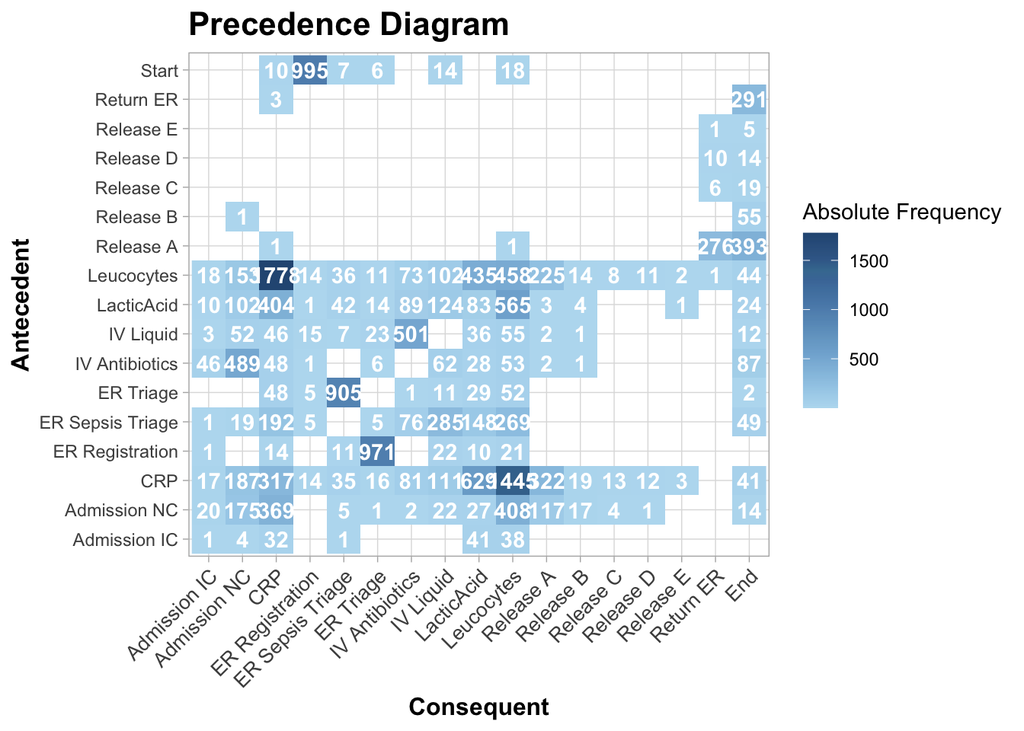

```r
#plot precedence diagram
sepsisData %>% precedence_matrix(type = "absolute") %>% plot +
theme(axis.text.x=element_text(size=10), axis.title.y = element_text(face = "bold", size= 12), axis.title.x = element_text(face = "bold", size= 12), plot.title = element_text(face = "bold", size = 16)) +
  ggtitle("Precedence Diagram")
```

#### Dotted Chart

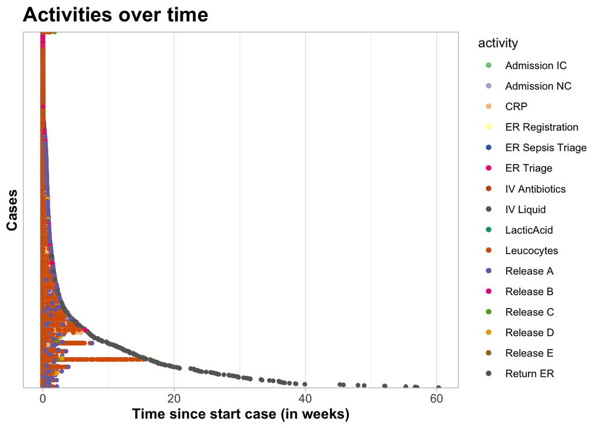

```r
#plot dotted chart
sepsisData %>% dotted_chart(x = "relative", y = "start") +
theme(axis.text.x=element_text(size=10), axis.title.y = element_text(face = "bold", size= 12), axis.title.x = element_text(face = "bold", size= 12), plot.title = element_text(face = "bold", size = 17)) +
  ggtitle("Activities over time")
```

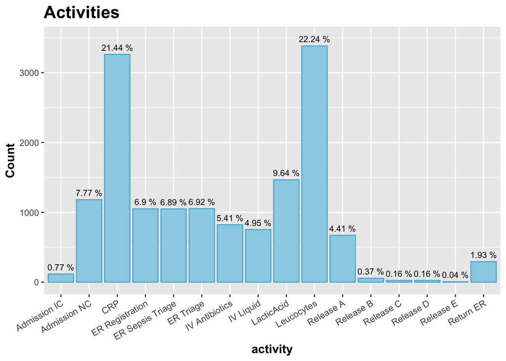

```r
ggplot(data = sepsisData, mapping = aes(x = activity, fill = activity)) +
  geom_bar(fill = "#9BD1E5", color = "#5DB5D5") +
  theme(axis.text.x=element_text(angle=30, hjust=1, size=9), axis.title.y = element_text(face = "bold", size= 12), axis.title.x = element_text(face = "bold", size= 12), plot.title = element_text(face = "bold", size = 17), legend.position = "none") +
  ylab("Count") +
  ggtitle("Activities") +
  geom_text(aes(label=paste(as.character(round(stat(prop), digits = 4) * 100), '%'), group=1), stat='count', nudge_y=100, size=3)
```

This bar chart shows the distribution and frequency of activities that occurred. _______________________________________________________________________________________________________________________________

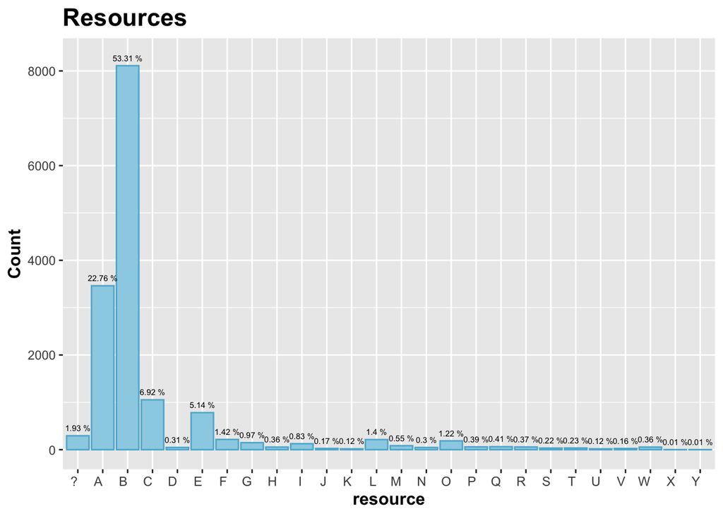

```r
ggplot(data = sepsisData, mapping = aes(x = resource, fill = resource)) +
  geom_bar(fill = "#9BD1E5", color = "#5DB5D5") +
  theme(axis.text.x=element_text(hjust=1, size=9), axis.title.y = element_text(face = "bold", size= 12), axis.title.x = element_text(face = "bold", size= 12), plot.title = element_text(face = "bold", size = 17), legend.position = "none") +
  ylab("Count") +
  ggtitle("Resources") +
  geom_text(aes(label=paste(as.character(round(stat(prop), digits = 4) * 100), '%'), group=1), stat='count', nudge_y=165, size=2, face = "bold")
```

This bar chart shows the distribution and frequency of resources that facilitated each activity. _______________________________________________________________________________________________________________________________

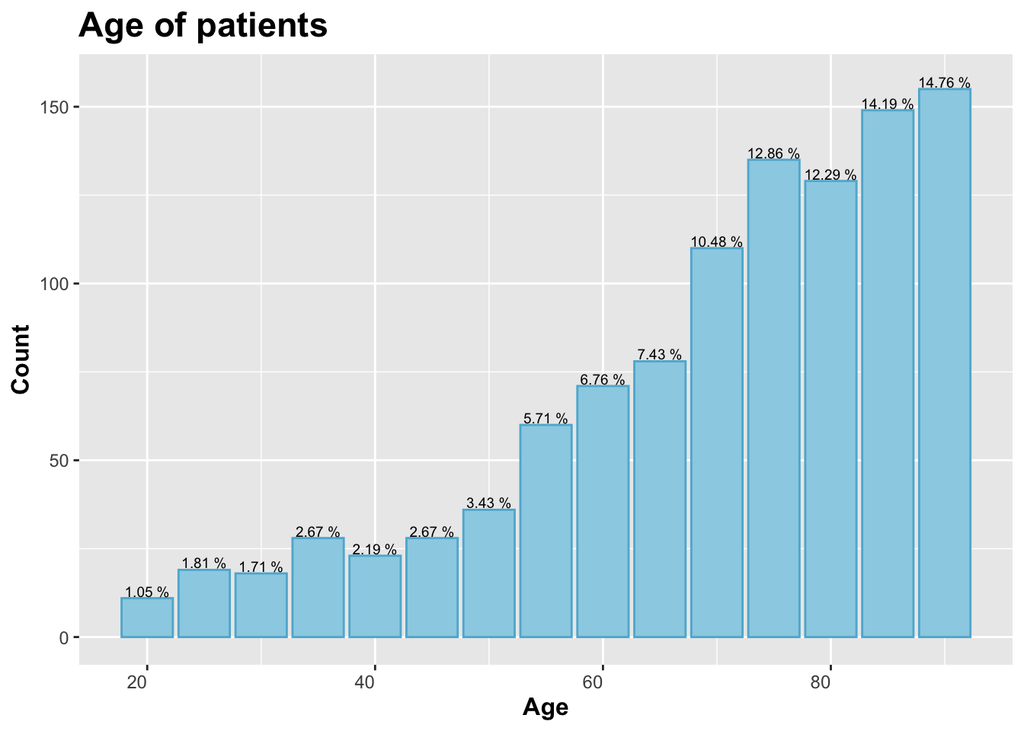

```r
sepsisAge <- sepsisData %>% filter(!is.na(age))

ggplot(data = sepsisAge, mapping = aes(x = age, fill = age)) +
  geom_bar(fill = "#9BD1E5", color = "#5DB5D5") +
  theme(axis.text.x=element_text(hjust=1, size=9), axis.title.y = element_text(face = "bold", size= 12), axis.title.x = element_text(face = "bold", size= 12), plot.title = element_text(face = "bold", size = 17), legend.position = "none") +
  ylab("Count") +
  xlab("Age") +
  ggtitle("Age of patients") +
  geom_text(aes(label=paste(as.character(round(stat(prop), digits = 4) * 100), '%'), group=1), stat='count', nudge_y=2, size=2.5, face = "bold")
```

### Statistical Modeling

Logistic regressions are similar to linear regressions, except that their output is restricted to the range [0,1]. In other words, the prediction/output is a probability.

**The goal is to predict the probability that an event is a patient discharge, i.e. Release A, Release B, Release C, Release D, or Release E occurs.**

Therefore, a logistic regression model must be used.

#### Transform Variables

```r
#get start time of cases
firstTime <- sepsisData %>% filter(activity == "ER Registration")
firstTime <- firstTime[,c(1,5)]
sepsisData <- inner_join(sepsisData, firstTime, by = "case_id")
names(sepsisData)[37] <- "case_begins"
names(sepsisData)[5] <- "timestamp"

as.POSIXct(sepsisData$timestamp, format = "%Y-%m-%d %H:%M:%OS")
as.POSIXct(sepsisData$case_begins, format = "%Y-%m-%d %H:%M:%OS")

#create timeDiff
sepsisData <- sepsisData %>% mutate(timeDiff = timestamp - case_begins)

#change null ages to 0
sepsisData$age[is.na(sepsisData$age)] <- 0
```

Another variable we will use for modeling is the amount of times a particular event occurs for a patient. So, the count of each event will be obtained for patients.

```r
#add frequency of event in case as new column
sepsisData <- sepsisData %>%
  group_by(case_id, activity) %>%
  mutate(frequency = n())
```

Since a logistic regression is used to predict a binary variable, the data must be transformed such that each entry in the “Activity” column is

- 1 when activity = “Release A”, “Release B”, “Release C”, “Release D”, or “Release E”
- 0 Otherwise

```r
#make activity column a binary variable
sepsisData$activity <- ifelse((sepsisData$activity == "Release A" | sepsisData$activity == "Release B" | sepsisData$activity == "Release C" | sepsisData$activity == "Release D" | sepsisData$activity == "Release E"), 1, 0)
```

#### Class Imbalance

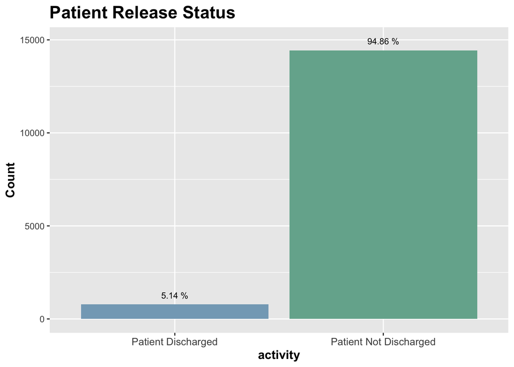

```r
freqTable <- table(sepsisData$activity)

#change labels to strings for the purpose of plotting
tempLabels <- sepsisData
tempLabels$activity <- ifelse(sepsisData$activity == 1, "Patient Discharged", "Patient Not Discharged")
ggplot(data = tempLabels, mapping = aes(x = activity)) +
  geom_bar(fill = c("#84A9C0", "#75B09C")) +
  theme(axis.text.x=element_text(size=10), axis.title.y = element_text(face = "bold", size= 12), axis.title.x = element_text(face = "bold", size= 12), plot.title = element_text(face = "bold", size = 17)) +
  ylab("Count") +
  ggtitle("Patient Release Status") +
  geom_text(aes(label=paste(as.character(round(stat(prop), digits = 4) * 100), '%'), group=1), stat='count', nudge_y=500, size=3)
```

We can see that the two binary categories are unbalanced, meaning that the important class we are trying to predict (a patient being discharged) occurs at a much smaller frequency than the less important class (a patient not being discharged). This means that the metrics used to evaluate the final model must account for this class imbalance.

#### Undersampling

In order to account for the class imbalance, we will **undersample the majority class**, i.e, sample fewer data points from the **“Patient Not Discharged”** class to ensure that it has the same number of data points as the **“Patient Discharged”**.

```
##
##     Patient Discharged Patient Not Discharged
##                    782                  14432
```

So, we will sample both the “Patient Discharged” class and the “Patient Not Discharged” class so so they have a 50:50 ratio.

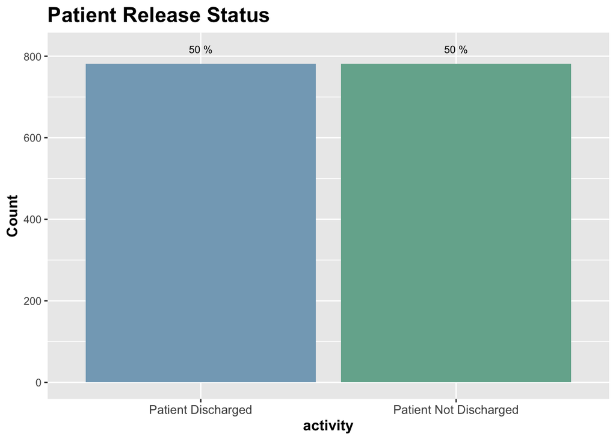

```
##
##     Patient Discharged Patient Not Discharged
##                    782                    782
```

```r
#undersample majority class
dischargedClass <- sepsisData %>% filter(activity == 1)
notDischargedClass <- sepsisData %>% filter(activity == 0)

notDischargedClass <- notDischargedClass[sample(nrow(notDischargedClass),782),]

sepsisData_new <- rbind(dischargedClass, notDischargedClass)


#change labels to strings for the purpose of plotting
tempLabels_after <- sepsisData_new
tempLabels_after$activity <- ifelse(sepsisData_new$activity == 1, "Patient Discharged", "Patient Not Discharged")


ggplot(data = tempLabels_after, mapping = aes(x = activity)) +
  geom_bar(fill = c("#84A9C0", "#75B09C")) +
  theme(axis.text.x=element_text(size=10), axis.title.y = element_text(face = "bold", size= 12), axis.title.x = element_text(face = "bold", size= 12), plot.title = element_text(face = "bold", size = 17)) +
  ylab("Count") +
  ggtitle("Patient Release Status") +
  geom_text(aes(label=paste(as.character(round(stat(prop), digits = 4) * 100), '%'), group=1), stat='count', nudge_y=35, size=3)
```

Now, both classes have the same frequency in the data set.

#### Logistic Regression Model

```r
sepsisData_new <- as.data.frame(sepsisData_new)

#train and test split
sampleIndx <- sample.split(sepsisData_new, SplitRatio = 0.70)
sepsisTrain <- subset(sepsisData_new, sampleIndx ==TRUE)
sepsisTest <- subset(sepsisData_new, sampleIndx ==FALSE)
sepsisTest_label <- sepsisTest$activity
```

So, the final logistic regression model is:

$P(event\,is\,a\,hospital\,discharge) = \alpha + TimeDiff + Age + Frequency$

### ROC Curve

In ROC curve analysis, an ROC curve is often used to determine the cutoff point for classification- i.e. the probability cutoff that determines which probabilities obtained by a logistic regression produce one class (1), and which produce the other class (0). In the context of this problem, we are looking for the number that will be the cutoff point for determining which events are **hospital discharge** (“Release A”, “Release B”, “Release C”, “Release D”, or “Release E”), and which are **not hospital discharges** (all other events).

In this case, the optimal cutoff will be the probability cutoff that gives the smallest classification error.

The ROC curve shows the performance of our logistic regression model at all probability cutoffs. It does this by plotting:

- True Positive Rate (the probability that an actual ****“Patient Discharge”**** will be classified as a **“Patient Discharge”**)
- False Positive Rate (the probability that an actual **“Patient not Discharged”** request will be classified as a **“Patient Discharge”**)

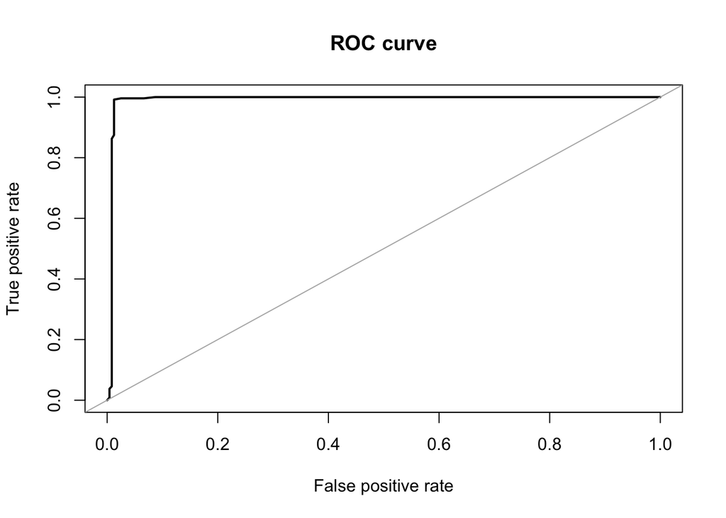

```r
#roc curve
roc <- roc.curve(sepsisTest$activity, log_reg_prob)
```

```r
#optimal cutoff
cutoff <- optimalCutoff(sepsisTest$activity, log_reg_prob, optimiseFor = "misclasserror")
cutoff
```

```
## [1] 0.6973357
```

So, the probability cutoff that gives the lowest misclassification error is **0.6973357**

#### Summary of Logistic Regression Model

Below is the regression output for the logistic regression model. The intercepts and coefficients of the model are provided, as well as statistics such as a Z-score and P-value for each term of the model.

```r
log_reg_pred <- ifelse(log_reg_prob > cutoff, 1, 0)
summary(log_reg)
```

```
##
## Call:
## glm(formula = activity ~ timeDiff + age + frequency, family = binomial("logit"),
##     data = sepsisTrain)
##
## Deviance Residuals:
##     Min       1Q   Median       3Q      Max
## -3.2591   0.0000   0.2860   0.8189   0.8569
##
## Coefficients:
##               Estimate Std. Error z value Pr(>|z|)
## (Intercept)  1.854e+01  3.852e+02   0.048   0.9616
## timeDiff     2.394e-07  1.239e-07   1.933   0.0532 .
## age         -7.197e-01  1.304e+02  -0.006   0.9956
## frequency   -1.773e+01  3.852e+02  -0.046   0.9633
## ---
## Signif. codes:  0 '***' 0.001 '**' 0.01 '*' 0.05 '.' 0.1 ' ' 1
##
## (Dispersion parameter for binomial family taken to be 1)
##
##     Null deviance: 1501.36  on 1082  degrees of freedom
## Residual deviance:  892.59  on 1079  degrees of freedom
## AIC: 900.59
##
## Number of Fisher Scoring iterations: 21
```

#### Classification Accuracy

```r
mean(log_reg_pred == sepsisTest_label)
```

```
## [1] 0.989605
```

#### Confusion Matrix

The Confusion Matrix is used to describe the performance of a classification model. It allows us to see the number of test data points that are:

```r
Prediction <- ifelse(log_reg_pred == 1, "Patient Discharge", "Not a Patient Discharge")
Actual <- ifelse(sepsisTest_label == 1, "Patient Discharge", "Not a Patient Discharge")
Prediction <- as.factor(Prediction)
Actual <- as.factor(Actual)

confMatrix <- table(Prediction, Actual)
confMatrix
```

```
##                          Actual
## Prediction                Not a Patient Discharge Patient Discharge
##   Not a Patient Discharge                     238                 2
##   Patient Discharge                             3               238
```

### Conclusion

The focus of this study was to better understand an sepsis patient data set, and develop a way to predict if a patient will be discharged. The data set was analyzed and visualized to obtain an understanding of its organization and the distributions of its variables and components. A process map illustrating the different types of hospital events was obtained to visualize the event log data and gain an understanding of the order and timely manner in which requests are processed. Finally, a logistic regression model was trained and tested to accurately predict which hospital events are discharges, and which are not. Further work can be done to verify and fine-tune this model to obtain a higher classification accuracy.

### References

1. https://www.bupar.net/eventdataR.html
2. https://www.bupar.net/
3. https://towardsdatascience.com/understanding-auc-roc-curve-68b2303cc9c5
4. https://ncss-wpengine.netdna-ssl.com/wp-content/themes/ncss/pdf/Procedures/NCSS/One_ROC_Curve_and_Cutoff_Analysis.pdf
5. https://www.mayoclinic.org/diseases-conditions/sepsis/symptoms-causes/syc-20351214
6. https://www.cdc.gov/sepsis/what-is-sepsis.html